# 2025年度 技術報告書

## 3.3 段組み

### 3.3.1 カラムとグリッド

`::::{.columns}`ブロックで囲むことによって、複数行に段組みして記述することができる。各行は`:::{.column width="50%"}`で幅を指定しながら囲むことができる。

**出力結果**

**コード**

```
hello.c
```

```c
#include <stdio.h>

int main(void)
{
    printf("Hello World!\n");
    return 0;
}
```

**結果**

hello.cのコンパイルと実行

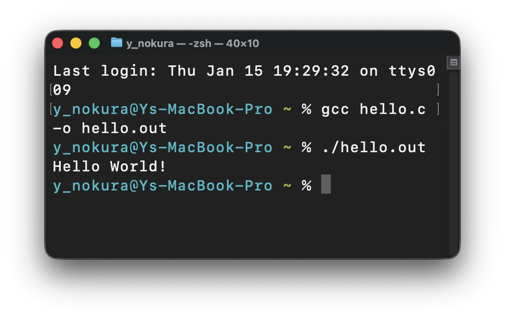

**書き方**

```
Quarto
```

```markdown
::::{.columns}
:::{.column width="39%"}

**コード**

#| code-line-numbers: true

#include <stdio.h>

int main(void)
{
    printf("Hello World!\n");
    return 0;
}

:::
:::{.column width="2%"}
:::
:::{.column width="59%"}

**結果**

![hello.cのコンパイルと実行](img/columns_01.jpg)

:::
::::
```

**ノート**

カラムはマージン（空白）が入らないため、`2%`程度の空白列を設けるようにすると良い。

また、Quarto独自機能である`::::{.grid}`で囲むことによって、あらかじめマージンがセットされた段組みを記述することができる。グリッド内は12分割されており、`:::{.g-col-6}`のように割合を指定する。

**出力結果**

**コード**

```
hello.c
```

```c
#include <stdio.h>

int main(void)
{
    printf("Hello World!\n");
    return 0;
}
```

**結果**

hello.cのコンパイルと実行

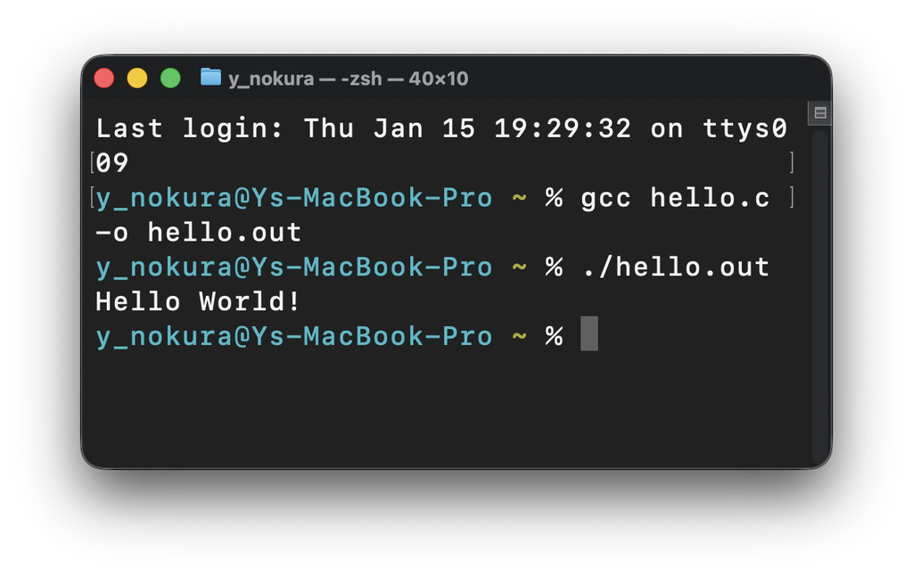

**書き方**

```
Quarto
```

```markdown
::::{.grid}
:::{.g-col-5}

**コード**

#| code-line-numbers: true

#include <stdio.h>

int main(void)
{
    printf("Hello World!\n");
    return 0;
}

:::
:::{.g-col-7}

**結果**

![hello.cのコンパイルと実行](img/columns_01.jpg)

:::
::::
```

カラムと比較して、図のキャプションに注目すると、空白列を入れていないのにグリッドの隙間に空白が入っているのがわかるだろう。

### 3.3.2 パネルタブ

`:::{.panel-tabset}`で囲むことによって、コンテンツをタブごとに切り替えて表示することができる。任意の見出し行（`#`）によって区切る。

**書き方**

```
Quarto
```

```markdown
:::{.panel-tabset}
###### カラム
`::::{.columns}`ブロックで囲むことによって、複数行に段組みして記述することができる。各行は`:::{.column width="50%"}`で幅を指定しながら囲むことができる。

###### グリッド
Quarto独自機能である`::::{.grid}`で囲むことによって、あらかじめマージンがセットされた段組みを記述することができる。グリッド内は12分割されており、`:::{.g-col-6}`のように割合を指定する。
:::
```

**出力結果**

**カラム**

`::::{.columns}`ブロックで囲むことによって、複数行に段組みして記述することができる。各行は`:::{.column width="50%"}`で幅を指定しながら囲むことができる。

**グリッド**

Quarto独自機能である`::::{.grid}`で囲むことによって、あらかじめマージンがセットされた段組みを記述することができる。グリッド内は12分割されており、`:::{.g-col-6}`のように割合を指定する。

## 3.4 その他

- HTMLタグの`<br>`を入れることにより、強制的に改行する事ができる。
- ハイパーリンクの後ろに{target=“_blank”}を入れると、リンクを新しいタブで開く事ができる。また`{.external target="_blank"}`とすると、リンクの後ろに外部サイトを表すアイコンが付く。
  - [Quarto公式](https://quarto.org)
- `:::{style="<css style>"}`で囲むことにより、ブロック内にCSSスタイルを指定できる。

**ヒント**

特に、`:::{style="margin-left: 2em;"}`は左に２文字分（`em`が文字単位）の余白を開けたスタイルを適用でき、箇条書き内に（下の画像のように）画像や（このブロックのように）コールアウトを入れるときに有効。

- （上と関連して）コードブロック（`{python style="margin-left: 2em;"}`）コールアウトブロック（`{.callout-tip style="margin-left: 2em;"}`）にも、ブロックで囲むことなく個別に余白やその他スタイルを指定可能。

**警告注意**

画像にも`![](img.jpg){style="margin-left: 2em;"}` のようにスタイルを指定できるが、キャプションには適用されない。

- YAMLヘッダーに`lightbox: true`を入れると写真をクリックしたときに拡大表示できる。

善光寺（写真をクリックして拡大）

[figure not shown]

## 3.5 参考になるサイト

- [私たちのR](https://www.jaysong.net/Rbook/)
  - [24 Quarto [基礎]](https://www.jaysong.net/RBook/quarto1.html)
  - [25 Quarto [文書]](https://www.jaysong.net/RBook/quarto2.html)
- [Quarto公式リファレンス（英語）](https://quarto.org/docs/reference.html)

# 4 開発環境の効率化

## 4.1 データベースの一元化

開発当初はSQLiteのデータベースを使用していたが、`.db`ファイルはGitHubリポジトリで管理されており、個々の開発環境に最新データがリアルタイムで反映されない問題があった。そのため、サーバー内でMySQLのDockerコンテナを立ち上げ、内部のMySQLデータベースでデータを管理するシステムに移行した。

同期は、`__init__.py`内にカスタムコマンド（`sync-db`）として実装している。

```
__init__.py
```

```python
# --- 中略 ---

# カスタムコマンド: flask sync-db
@app.cli.command("sync-db")
def sync_db():
    """MySQLからローカルSQLiteへデータを同期する"""
    print("DATABASE_URL:", mysql_url)
    print("use_mysql:", use_mysql)
    if not use_mysql:
        print("エラー: DATABASE_URLが設定されていないか、MySQLに接続できません。")
        return

    try:
        from .models import Festivals, User, UserFavorite, EditLog, Review, InformationSubmission, Passkey
        sqlite_engine = create_engine(sqlite_url)

        # 同期するモデルのリスト
        models = [Festivals, User, UserFavorite, EditLog, Review, InformationSubmission, Passkey]

        # スキーマの自動修復（不足カラムの追加）
        print("SQLiteのスキーマを確認中...")
        inspector = inspect(sqlite_engine)
        with sqlite_engine.connect() as conn:
            for model in models:
                if inspector.has_table(model.__tablename__):
                    print(f"テーブルを削除中（スキーマ更新）: {model.__tablename__}")
                    conn.execute(text(f"DROP TABLE {model.__tablename__}"))
                    conn.commit()

        print("SQLiteのスキーマを更新中...")
        db.metadata.create_all(sqlite_engine)

        with sqlite_engine.connect() as sqlite_conn:
            with sqlite_conn.begin():
                for model in models:
                    print(f"同期中: {model.__tablename__}...")
                    items = model.query.all()

                    # SQLite側の既存データを削除して入れ替え
                    sqlite_conn.execute(model.__table__.delete())

                    data_to_sync = []
                    for item in items:
                        row = {c.name: getattr(item, c.name) for c in model.__table__.columns}
                        data_to_sync.append(row)

                    if data_to_sync:
                        sqlite_conn.execute(model.__table__.insert(), data_to_sync)

        print("同期が完了しました！ instance/fesData.db が更新されました。")
    except Exception as e:
        print(f"同期失敗: {e}")

# --- 中略 ---
```

**1**

FlaskのCLIコマンドとして登録するデコレータ。これにより `flask sync-db` コマンドが使用可能になる。

**2**

環境変数等でMySQLの使用が設定されていない場合は処理を中断する。

**3**

同期先となるローカルのSQLiteデータベースへの接続エンジンを作成する。

**4**

スキーマ（テーブル構造）の変更に対応するため、既存のテーブルを一度削除（`DROP`）する。

**5**

最新のモデル定義に基づいて、SQLite側にテーブルを再作成する。

**6**

MySQL（Flaskアプリが接続しているメインDB）から、対象モデルの全データを取得する。

**7**

取得したデータを辞書形式に変換し、SQLiteデータベースに一括挿入する。

*※コード内の数字にホバーすると解説が表示される。*

## 4.2 公開鍵による開発メンバーの接続

まず、開発リーダーのサーバーのアカウントに開発メンバーをどう接続させるかを考えた。結果として採用したのが公開鍵である。

公開鍵を使う利点としては、

- 設定が簡単
- それぞれの鍵に権限を設定することができる
- 行を消すだけで鍵を使えなくすることができ、メンバーから離脱した時の後処理がこちらのみで済む

が挙げられる。

### 4.2.1 SSHキーペアの生成

各メンバーのPCで以下のコマンドを実行し、SSHキーペア（秘密鍵と公開鍵）を生成する。

```
bash
```

```bash
ssh-keygen -t ed25519
```

`-t ed25519`とすることで、暗号化方式に、現在最も推奨されている **Ed25519** を指定する。RSAよりも鍵長が短く、かつセキュリティ強度が高い。

コマンドを実行すると、保存場所やパスフレーズを聞かれるが、全てエンターキー（デフォルト設定）で進めて問題ない。生成が完了すると、`~/.ssh/id_ed25519.pub` に公開鍵が保存される。

### 4.2.2 サーバーへの登録

リーダー（サーバー管理者）は、メンバーから送られてきた公開鍵（`id_ed25519.pub`の中身）を、サーバーの `~/.ssh/authorized_keys` に追記する。

- リーダーの鍵: 全権限を持つ
- メンバーの鍵: ポートフォワーディングとSCPのみ許可（シェルログイン不可）

```
.ssh/authorized_keys
```

```
# リーダー（自分）の鍵
ssh-ed25519 <公開鍵> j22069yn

# メンバーの鍵
no-pty,restrict,port-forwarding,permitopen="127.0.0.1:3316",command="/home/j22069yn/.ssh/scp-and-tunnel.sh" ssh-ed25519 <公開鍵> j22037yk
no-pty,restrict,port-forwarding,permitopen="127.0.0.1:3316",command="/home/j22069yn/.ssh/scp-and-tunnel.sh" ssh-ed25519 <公開鍵> j22069ra
```

- `restrict`: 全ての機能を無効化する（PTY割り当て、ポート転送、エージェント転送など）。これをベースに、必要な機能だけを許可していくホワイトリスト方式をとる。
- `no-pty`: ターミナル（対話型シェル）の割り当てを禁止する。これにより、サーバーにログインしてコマンド操作をされるのを防ぐ。
- `port-forwarding`: `restrict`で無効化されたポートフォワーディング機能を再度有効化する。
- `permitopen="127.0.0.1:3316"`: ポートフォワーディングの接続先を、ローカルのMySQLポート（3316）のみに制限する。他のポートへのアクセスは拒否される。
- `command="..."`: ユーザーがどんなコマンドを実行しようとしても、強制的に指定されたスクリプト（`scp-and-tunnel.sh`）を実行させる。

### 4.2.3 実行コマンドの制限スクリプト

`authorized_keys`の`command`オプションで指定されたスクリプトにより、SCP（ファイル転送）とポートフォワーディング以外の操作をブロックする。

```
scp-and-tunnel.sh
```

```bash
#!/bin/bash

case "$SSH_ORIGINAL_COMMAND" in
    scp*|*sftp-server*|internal-sftp)
        # コマンドを実行
        $SSH_ORIGINAL_COMMAND
        ;;
    "")
        # トンネル用
        sleep infinity
        ;;
    *)
        # メッセージを標準エラー出力(>&2)に流す
        echo "Access Denied: Only SCP/SFTP and Port-forwarding are allowed." >&2
        exit 1
        ;;
esac
```

**1**

`SSH_ORIGINAL_COMMAND`: ユーザーがSSH接続時に実行しようとした元のコマンドがこの環境変数に格納される。

**2**

scp*: 元のコマンドがscp（ファイル転送）で始まる場合、そのまま実行を許可する。これにより環境変数の同期（sync:env）が可能になる。

**3**

““（空文字）: コマンドが指定されていない場合（ssh -Nなど、ポートフォワーディングのみを目的とする場合）、sleep infinityを実行して接続を維持する。これがないと、コマンド終了と同時に接続が切れてしまい、トンネルが維持できない。

**4**

*（その他）: 上記以外（通常のシェルコマンドなど）は全て拒否し、エラーメッセージを表示して切断する。

## 4.3 Concurrently

Npmライブラリの **Concurrently** を使用することにより、`npm run ***`コマンドで複数のコマンドを同時実行することができる。Reactの開発サーバーを立ち上げる（`npm start`）ときにFlaskのサーバーも自動で起動（`flask run --debug`）することができる。

```
bash
```

```bash
npm install concurrently
```

### 4.3.1 `package.json`の追記

プロジェクトのルートディレクトリの`package.json`に`npm run`で実行するコマンドを`"scripts" { ... }`追記する。

```
package.json
```

```json
{
  "name": "shinshu-fesnav-monorepo",
  "version": "1.0.0",
  "private": true,
  "scripts": {
    "tunnel": "ssh -4 -L 3316:127.0.0.1:3316 j22069yn@133.242.152.98 -N",
    "sync:env": "scp -i ~/.ssh/id_ed25519 j22069yn@133.242.152.98:/home/j22069yn/shinshu-fesnav/.env.local ./backend/.env.local",
    "predev": "npm run sync:env",
    "backend:dev": "cd backend && cross-env PYTHONUNBUFFERED=1 pipenv run flask run --debug --host=0.0.0.0",
    "backend:prod": "cd backend && cross-env FLASK_ENV=production pipenv run gunicorn --workers 4 --bind 0.0.0.0:5052 \"app:create_app()\"",
    "frontend": "cd frontend && cross-env DEBUG=http-proxy-middleware* npm start",
    "sync:db": "wait-on tcp:127.0.0.1:3316 && echo 'Tunnel connected, syncing DB...' && cd backend && pipenv run flask sync-db",
    "build-frontend": "cd frontend && npm run build",
    "qr": "node ShowQR.js",
    "dev": "concurrently --kill-others-on-fail --handle-input --kill-signal SIGINT \"npm:tunnel\" \"npm:backend:dev\" \"npm:frontend\" \"npm:sync:db\" \"npm:qr\"",
    "prod": "npm run build-frontend && npm run backend:prod"
  },
  "devDependencies": {
    "concurrently": "^8.2.2",
    "qrcode-terminal": "^0.12.0",
    "wait-on": "^7.2.0"
  },
  "dependencies": {
    "@fullcalendar/list": "^6.1.19",
    "@fullcalendar/timegrid": "^6.1.19",
    "cross-env": "^10.1.0",
    "leaflet": "^1.9.4",
    "react-leaflet": "^5.0.0"
  }
}
```

各スクリプトについては以下で述べる。

### 4.3.2 SSHトンネル

```json
{
  "tunnel": "ssh -4 -L 3316:127.0.0.1:3316 j22069yn@133.242.152.98 -N"
}
```

開発用PCから本番サーバーのMySQLデータベース（ポート3316）に安全に接続するために、SSHポートフォワーディングを行う。これにより、ローカルの3316番ポートへのアクセスが、暗号化されたトンネルを通じてサーバーの3316番ポートへ転送される。

### 4.3.3 環境変数の同期

```json
{
  "sync:env": "scp -i ~/.ssh/id_ed25519 j22069yn@133.242.152.98:/home/j22069yn/shinshu-fesnav/.env.local ./backend/.env.local",
}
```

サーバー上にある最新の環境変数ファイル（`.env.local`）をローカルの開発環境にコピーする。これにより、APIキーやデータベースの接続情報などをチーム内で安全に共有・同期できる。

### 4.3.4 `predev`

```json
{
  "predev": "npm run sync:env"
}
```

`npm run dev`コマンドが実行される直前に自動的に実行されるスクリプト（プレフック）。ここでは上記のsync:envを実行し、開発サーバー起動前に必ず環境変数を最新化するようにしている。

### 4.3.5 バックエンドサーバーの起動

```json
{
  "backend:dev": "cd backend && cross-env PYTHONUNBUFFERED=1 pipenv run flask run --debug --host=0.0.0.0",
  "backend:prod": "cd backend && cross-env FLASK_ENV=production pipenv run gunicorn --workers 4 --bind 0.0.0.0:5052 \"app:create_app()\""
}
```

`backend:dev`は開発用で、ホットリロード（コード変更時の自動再起動）が有効なデバッグモードでFlaskサーバーを起動する。`backend:prod`は本番用で、Gunicornを使用して本番環境向けの構成でサーバーを起動する。

### 4.3.6 フロントエンドサーバーの起動

```json
{
  "frontend": "cd frontend && cross-env DEBUG=http-proxy-middleware* npm start"
}
```

Reactの開発サーバーを起動する。

### 4.3.7 フロントエンドのビルド

```json
{
  "build-frontend": "cd frontend && npm run build"
}
```

本番環境向け（`backend:prod`）に、Reactアプリケーションの静的ファイル（HTML/CSS/JacvaScript）をビルドする。

### 4.3.8 データベースの同期

```json
{
  "sync:db": "wait-on tcp:127.0.0.1:3316 && echo 'Tunnel connected, syncing DB...' && cd backend && pipenv run flask sync-db"
}
```

`wait-on`コマンドを使用してSSHトンネル（3316番ポート）の開通を待ち、接続が確認でき次第、`__init__.py`に入っているFlaskのカスタムコマンド`sync-db`を実行して、データベースのマイグレーションを行う。

### 4.3.9 QRコードの表示

```json
{
  "qr": "node ShowQR.js"
}
```

同じWi-Fiネットワーク内のスマートフォンから開発中の画面を確認できるよう、ローカルIPアドレスのURLをQRコードとしてターミナルに表示する。

```
showQR.js
```

```javascript
const qrcode = require('qrcode-terminal');
const { networkInterfaces } = require('os');

// ローカルIPアドレスを取得する関数
function getLocalIp() {
  const nets = networkInterfaces();
  for (const name of Object.keys(nets)) {
    for (const net of nets[name]) {
      // IPv4 で内部接続用(127.0.0.1)ではないものを探す
      if (net.family === 'IPv4' && !net.internal) {
        return net.address;
      }
    }
  }
  return 'localhost';
}

const ip = getLocalIp();
const port = 3000; // フロントエンドのポート番号
const url = `https://${ip}:${port}`;

console.log('\nスマホ実機確認用QRコード:');
console.log(`URL: ${url}`);
qrcode.generate(url, { small: true });
```

**1**

Node.jsの標準モジュールである`os`から`networkInterfaces`を取得し、PCが持っているネットワークアダプタの一覧を取得する。

**2**

ループ処理で「IPv4」かつ「内部接続用（127.0.0.1など）ではない」アドレスを探し出す。これがWi-Fiなどで割り当てられたローカルIPアドレスとなる。

**3**

取得したIPアドレスとポート番号（3000）を組み合わせてURLを生成する。

**4**

`qrcode-terminal`ライブラリを使用して、生成したURLをQRコードに変換し、ターミナルに出力する。

### 4.3.10 開発サーバーの起動

```json
{
  "dev": "concurrently --kill-others-on-fail --handle-input --kill-signal SIGINT \"npm:tunnel\" \"npm:backend:dev\" \"npm:frontend\" \"npm:sync:db\" \"npm:qr\"",
  "prod": "npm run build-frontend && npm run backend:prod"
}
```

# 5 コンテナ技術

## 5.1 コンテナとは

コンテナ化すると、アプリケーションとその実行に必要なすべての要素（ライブラリ・設定ファイルなど）をコンテナと呼ばれる軽量で独立したパッケージにまとめて隔離できる。実行はその場所のホストOS（PCだったらPCのOS、サーバーだったらサーバーにインストールしたOS）が行う。

**コンテナと仮想マシンの比較**

| 特徴 | コンテナ | 仮想マシン（VM） |
| --- | --- | --- |
| **OSの包含** | ホストOSのカーネルを共有（ゲストOSなし） | 独自のゲストOSを内包 |
| **サイズ・速度** | 軽量、起動が数秒と非常に速い | 重い、OSの起動が必要なため遅い |
| **OSの種類** | ホストOSと同じカーネル（LinuxならLinux）しか動かせない | ハイパーバイザ上で異なるOS（例: Windows上でLinux）を動かせる |

**ノートコンテナ化のメリット**

一度ビルドすればどこでも実行できるので高い移植性と一貫性を持つ。またゲストOSを必要としないため軽量・高速である。

## 5.2 Dockerイメージのファイル構造

Dockerのファイルシステムは、何層もの「差分」が重なってできている。この層を**レイヤー**と呼ぶ。

- **ベースイメージ層**: OSの基本部分。読み取り専用。
- **ミドルウェア/アプリ層**: `pip`や`npm`で入れたライブラリや、コピーしたソースコード。これらもビルド後は読み取り専用になることによって、どの環境でも同じ実行環境を実現できる。

複数のコンテナを起動しても、下の「読み取り専用」部分は共通して使い回せるため、ディスク容量を劇的に節約できるようになっている。

## 5.3 Dockerのイメージとコンテナ

コンテナは、**イメージによって積み重ねられたファイルと、隔離され動的な実行部分の組み合わせ**でできている。

- **Namespaces（名前空間）**: コンテナごとに独立した環境（プロセスID、ネットワーク、マウントポイントなど）を提供するためのLinuxカーネルの機能。これにより、コンテナ内のプロセスは他のコンテナやホストシステムから隔離される。
- **Cgropus（コントロールグループ）**: メモリ使用量やCPU使用率の上限を定め、コンテナに対してリソースを制限する。これにより、1つのコンテナが暴走してもサーバー全体がダウンするのを防ぐことができる。
- **Config（設定ファイル）**: ファイルとプロセスだけでなく、実行時の「指示書」を持っている。これはJSON形式のメタデータとして保存される。
  - ENTRYPOINT / CMD: 起動したときに最初に実行するコマンド。
  - ENV: 環境変数。
  - User: どのユーザー（rootかそれ以外か）で実行するか。
  - WorkingDir: 作業ディレクトリの位置。

コンテナには、このような**動的レイヤー**がイメージレイヤーに追加されているだけである。

## 5.4 DockerとApptainer（Singularity）

### 5.4.1 Apptainer （Singularity）について

[Apptainer](https://apptainer.org)（旧名: Singularity）は、HPC (High Performance Computing) 環境向けに開発されたコンテナプラットフォームである。Dockerと違い、コマンドの実行に管理者権限が不要なため、共用のサーバーなどで管理者権限を持つアカウントを持っていない場合に有効である。

### 5.4.2 DockerとApptainer（Singularity）の比較

| 特徴 | Docker | Apptainer（Singularity） |
| --- | --- | --- |
| **主な用途** | Webアプリケーション、マイクロサービス開発など | HPC、科学技術計算、再現性の高い研究 |
| **実行権限** | 基本的にroot権限が必要 | 一般ユーザー権限で実行可能 |
| **イメージ形式** | レイヤー構造 | 単一のファイル（SIF） |
| **セキュリティ** | root権限での実行がセキュリティリスクになりうる | ユーザー権限で実行するため、より安全 |

### 5.4.3 DockerからApptainerへの変換フロー

サーバー（特にHPCのような共有環境）では、セキュリティ上の理由から管理者権限で動くDockerを直接利用できないことが多い。その場合、ローカル環境で作成したDockerイメージをサーバー上でApptainer（Singularity）形式に変換して利用するのが一般的なワークフローである。

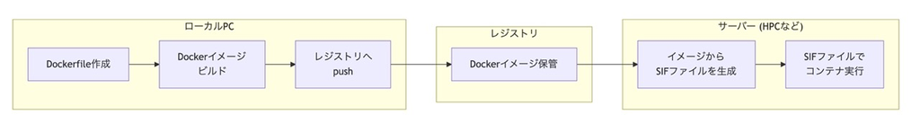

## 5.5 Docker環境の構築

### 5.5.1 Docker CLIで構築する方法（Windows・Linuxの場合）

**ノート**

Linuxの場合は、WSLの手順はスキップし、WSLを読み替えて進めてほしい。

`Win R`で「ファイル名を指定して実行」を開き、`pwsh`と入力してOKを押すとPowerShellが開く。

まずはWSLがインストールされているかを確認するため、以下のコマンドを実行。

```
psh
```

```bash
wsl -v
```

「Linux用Windowsサブシステムがインストールされていません」などと表示され、WSLのバージョン情報が出てこない場合は、以下を参照してセットアップする。

**WSLのセットアップ**

**ヒントWSLとは**

[WSL（Windows Subsystem for Linux）](https://learn.microsoft.com/ja-jp/windows/wsl/about)とは、Windows上でLinuxのコマンドラインツールやアプリケーション、GUIアプリをネイティブに実行できるようにするWindowsの機能である。Dockerの動作にはLinuxエンジンが必要だが、WindowsではWSLにより、容量の大きいDocker Desktopを使用せずとも、軽量かつ高速にコンテナ環境を構築・実行することが可能である。

PowerShellを**管理者権限で**起動し、`wsl --install`を実行。

**ヒントWSLインストール中にエラーが発生した場合**

```
psh
```

```
The Windows Subsystem for Linux optional component is not enabled.
Please enable it and try again.
Error code: Wsl/Service/CreateInstance/CreateVm/0x80370102
```

もしこのようなエラーが出た場合、WSL機能が無効になっている。特に古いバージョンのWindows 10で出やすい。

コントロールパネルを開き、

> プログラム ＞ プログラムと機能 ＞ Windowsの機能の有効化または無効化

の順に選択し、「Windows Subsystem for Linux」の項目にチェックを入れて再起動すれば機能が有効になる。

インストールが完了したら、PowerShellを再起動する。

次に、`wsl.exe --install ubuntu`でWSLにUbuntuをインストールする。

次にアカウント設定に進み、`Create a default Unix user account:`と聞かれるので、デフォルトのユーザー名を指定。`New password:`でパスワードを指定し、`Retype new password:`で確認のため再度入力。`passwd: password updated successflly`と出てきたらセットアップ完了。

**ノート**

以後は管理者権限でなくても`wsl`コマンドでLinux環境に入れる。

WSL上のLinuxにDockerをインストールしていく。`wsl`コマンドでLinuxのターミナルに入る。

```
bash
```

```bash
curl -fsSL https://get.docker.com -o get-docker.sh
sudo sh get-docker.sh
```

上記のコマンドでインストールできる。`sudo`は管理者権限で実行するコマンドなので、Ubuntuのパスワードを聞かれたら入力する。

**ノート**

`WSL DETECTED: We recommend using Docker Desktop for Windows.`と出てくるが、Docker Desktopを推奨する旨のアラートメッセージなので無視して良い。20秒ほど待つと`sh -c apt-get -qq update >/dev/null`が表示され、インストールが開始する。

```
bash
```

```
...
INFO: Docker daemon enabled and started


 sh -c docker version
...
```

このようにDockerデーモンが開始した旨のメッセージが出たらインストール完了。

次に、`sudo`なしでも`docker`コマンドを使えるようにするため、以下のコマンドを実行し、現在のユーザーに権限を付与する。

```
bash
```

```bash
sudo usermod -aG docker $USER
```

`exit`で一度WSLを抜け、`wsl`で再ログインする。`docker -v`でバージョンが確認できたら、セットアップ完了。

**ヒントバージョン情報が表示されない場合**

再起動後にDockerデーモンが起動していない可能性があるので、`sudo service docker start`を実行する。`* Starting Docker: docker`と表示されたら`docker`コマンドが使えるようになる。

### 5.5.2 Docker Desktopで構築する方法（macOSの場合）

Docker Desktopをインストールすると、LinuxエンジンとDockerのCLIツールが一括でセットアップされるため、よほどのことがない限りはDesktop版のインストールを推奨する。

- [macOS版Docker Desktop](https://docs.docker.com/desktop/setup/install/mac-install/)

**ヒントCLIツールのみでは動作しない**

Macにおいて、Homebrew等でCLIツール（`docker`コマンド）をインストールするだけではDockerは動作しない。Dockerは「操作を行うCLI」と「実行を担うLinuxエンジン」で構成されるが、macOS上には肝心のLinuxエンジンが存在しないためである。

## 5.6 DockerによるWebアプリのイメージ化

開発環境ではフロントエンドとバックエンドのポートが分かれている（デフォルトではフロントエンドは3000番ポート、バックエンドは5000番ポート）が、Reactを静的ファイルとして書き出すことで、デプロイ時には一つにまとめることができる。

**ノート開発環境で２つのポートが使用される理由**

開発環境では、Reactの開発サーバー（Create React App）が**コードを変更するとすぐに画面に反映される機能（ホットリロード）**を持つため、フロントエンド専用のポートが用意されている。

### 5.6.1 ポート統合のロジック

これを実現するには、Reactを静的ファイルとしてビルドし、Flaskから配信する形に変更する。

1. **Reactをビルド**: `npm run build`コマンドを実行すると、HTML・CSS・JavaScriptの静的ファイルが生成される。
2. **Flaskに統合**: 生成された静的ファイルを、Flaskのフォルダ内に配置する。
3. **Flaskだけを起動**: Flaskサーバーに「APIの処理」と「Reactの画面表示」の両方を担当させる。

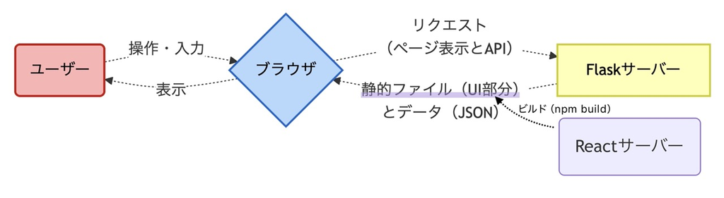

### 5.6.2 フロントエンド（React）のコンテナ化

Reactのコンテナ化には、2つのファイルが必要である。

1. `package.json`: `node`の必要ライブラリをまとめたファイル。`npm`によって自動生成される。
2. `Dockerfile`: Dockerにシステムの仕様を伝える「仕様書」のようなもの。Dockerはこのファイルを参照しながらシステムを構築する。

#### Dockerfileの作成

ReactのDockerfileでは、以下の流れで静的ファイルを書き出す処理を行う。

1. Node.js環境で`npm install`と`npm run build`を実行し、Reactアプリの静的ファイルを生成する。
2. `scratch`（空のイメージ）をベースとし、ビルドステージで生成された静的ファイルだけをコピーする。これにより、`node_modules`のような開発時にしか使わない巨大なファイルが最終的なコンテナに含まれなくなる。

```
/frontend/Dockerfile
```

```
FROM node:20-alpine AS builder
WORKDIR /app
COPY package.json package-lock.json ./
RUN npm install
COPY . .
RUN npm run build

FROM scratch
COPY --from=builder /app/build /
```

### 5.6.3 バックエンド（Flask）のイメージ化

1. `pipfile`: `pipenv`を使用して管理してるディレクトリの`pip`の依存関係をまとめたファイル。使用されているPythonパッケージとバージョンが記載されている。

**ヒント`pipenv`について**

`pipenv`は、Pythonにおけるパッケージ管理と仮想環境管理を統合したツールである。従来の`pip`（パッケージ管理）と`virtualenv`（仮想環境）を組み合わせた機能を持ち、`Pipfile`と`Pipfile.lock`という2つのファイルを用いて依存関係を厳密に管理する。

- **Pipfile**: インストールしたいパッケージ名を記述するファイル（`requirements.txt`の上位互換）。
- **Pipfile.lock**: 実際にインストールされたパッケージのバージョンやハッシュ値を記録するファイル。これにより、どの環境でも完全に同じライブラリ構成を再現できる。
2. `nginx.conf`: Flaskサーバー（Gunicorn）の前に立ち、クライアントからのリクエストをHTTPSで受け取り、Reactの静的ファイルの配信とAPIリクエストの中継を効率的に行う。

**ノート**

ファイル自体はイメージには含まれず、サーバーにおいてあるものがバインドマウントされる。これにより、イメージをビルドし直さなくても`nginx.conf`の内容を書き換えるだけでNginxの挙動を調整することができる。

3. `Dockerfile`: フロントエンドのDockerfileと役割は同じ。

#### Dockerfileの作成

FlaskのDockerfileでは、以下の流れで実行環境を構築する。

1. **ベースイメージ**: 軽量な`python:3.13-slim`を使用し、Nginxやビルドに必要なツール（gccなど）をインストールする。
2. **権限設定**: Apptainer（Singularity）での実行を考慮し、非ルートユーザーでもNginxが動作するようにログや一時ディレクトリの権限を調整する。
3. **依存関係**: `pipenv`を用いて`Pipfile`から必要なPythonパッケージをシステム全体にインストールする。
4. **起動設定**: 環境変数を用いてNginxの設定ファイルを動的に生成し、Nginx（Webサーバー）とGunicorn（APサーバー）を同時に起動する。

```
/backend/Dockerfile
```

```
FROM python:3.13-slim

RUN apt-get update && apt-get install -y nginx gettext-base gcc python3-dev libffi-dev libssl-dev \
    && rm -rf /var/lib/apt/lists/*

RUN chmod -R 777 /var/log/nginx /var/lib/nginx /run

WORKDIR /app

RUN pip install pipenv
COPY Pipfile Pipfile.lock ./
RUN pipenv install --system --deploy

COPY . .

RUN mkdir -p /usr/share/nginx/html /etc/nginx/certs

EXPOSE 5051

CMD export PORT=${PORT:-5051} && \
    export SERVER_NAME=${SERVER_NAME:-localhost} && \
    export GUNICORN_PORT=${GUNICORN_PORT:-5052} && \
    envsubst '$PORT $SERVER_NAME $GUNICORN_PORT' < /app/nginx.conf \
    > /etc/nginx/sites-enabled/default && \
    nginx && \
    exec gunicorn --bind 127.0.0.1:${GUNICORN_PORT} --workers 4 "app:create_app()"
```

### 5.6.4 Docker Hubへのログイン（CLI上）

プッシュするリポジトリが非公開の場合、ログインの必要がある。

```
bash
```

```bash
docker login -u <username>
```

`Login Succeeded`の表示でログイン完了。

**重要**

- `-p`オプションでパスワードを指定することもできるが、（特にサーバーの場合）`.bash_history`にコマンドの履歴が残るため避ける。
- `-u`オプションをつけないと、ブラウザログインになってしまい、LimaやWSLなどのCUI環境だとログインできない。

**ヒントソーシャルログインを使用していてパスワードがない場合**

「Googleで続行」などソーシャルログインを使用していてパスワードがない場合は、**Personal access tokens（PAT）**を使用することができる。

1. [アカウント設定](https://app.docker.com/)を開き、「Settings」＞「Personal access tokens」を開く。
2. 「Generate new token」からトークンを作成。
3. 下図の赤枠内がトークンなのでこれをパスワードの代わりに入力する。

[figure not shown]

**ノート**

現在のログイン状態を確認したい場合は、`docker login`を実行し、`[Username: <username>]`の部分から確認可。

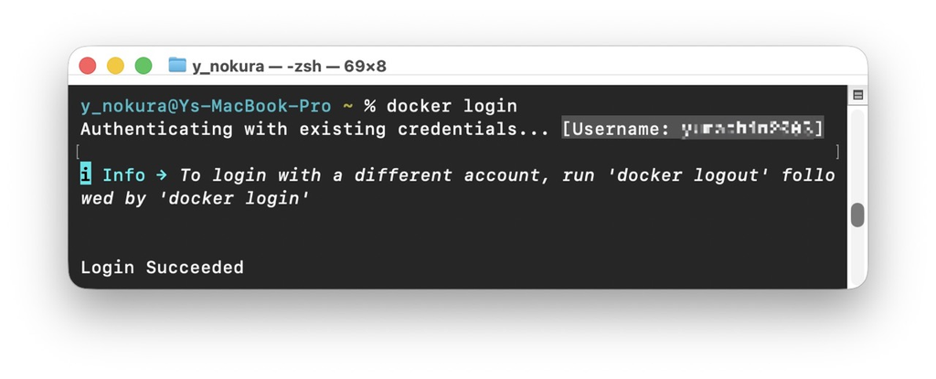

または、Linuxの場合`docker info | grep Username`でも確認可。ただしMacではログイン情報がキーチェーンに暗号化して保存されるため確認不可、Windowsでは未検証。

### 5.6.5 Docker Hubであらかじめ非公開リポジトリを作成する

リポジトリはプッシュ時に存在しない名前だった場合に自動で作成されるが、**デフォルトでPublic（全体公開）になってしまう**ため、非公開リポジトリで管理する場合はあらかじめDocker Hubでリポジトリを作成しておく。

1. [Docker Hub](https://hub.docker.com)にブラウザでログイン。右上の「Sign in」から。

[figure not shown]

2. 「Repositories」タブから「Create Repository」をクリック。

[figure not shown]

3. 「Repository Name」を入力し、「Visibility」（公開範囲）を「Private」に変更。

[figure not shown]

**重要**

ここで決めた名前と、ローカルで`docker tag`する時の名前は完全に一致させる必要がある。

**ノート**

非公開リポジトリは無料版アカウントだと一つしか作れないため、複数のイメージがあるコンテナでは使用不可だった。

4. 「Create」をクリックしリポジトリを作成。

[figure not shown]

### 5.6.6 Dockerイメージのプッシュ

1. **イメージのビルド**

```
bash
```

```bash
# docker build <ディレクトリ> -t <イメージ名>
docker build ~/shinshu-fesnav/backend -t shinshu-fesnav-backend
docker build ~/shinshu-fesnav/frontend -t shinshu-fesnav-frontend
```

**ノート**

イメージが正常に作成されたか確認するには、以下を実行。

```
bash
```

```bash
docker images
```

2. **イメージのタグ付け**

```
bash
```

```bash
# docker tag <イメージ名> <リポジトリ>:<タグ>
docker tag shinshu-fesnav-backend \
  yumachin2003/shinshu-fesnav-backend:v0
docker tag shinshu-fesnav-frontend \
  yumachin2003/shinshu-fesnav-frontend:v0
```

`:v0`の部分がリポジトリ上のタグになり、一般的にはバージョン番号を付加する。

リポジトリがバージョン番号のタグで管理されている様子

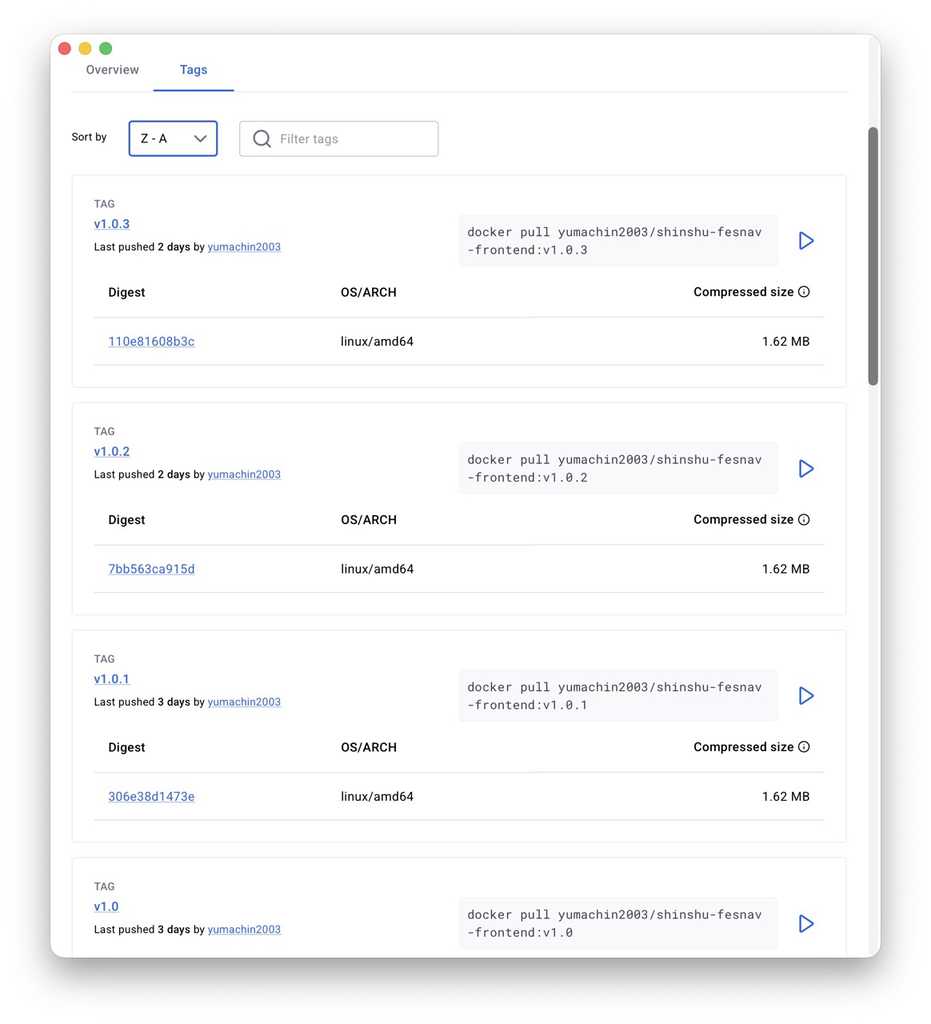

3. **イメージのプッシュ**

```
bash
```

```bash
# docker push <リポジトリ>:<タグ>
docker push yumachin2003/shinshu-fesnav-backend:v0
docker push yumachin2003/shinshu-fesnav-frontend:v0
```

**重要**

ビルドする際には、**CPUアーキテクチャの違い**に注意する。

```
bash
```

```bash
## ビルド側のCPUアーキテクチャを確認
docker info | grep Architecture

## サーバー側のCPUアーキテクチャを確認
uname -m
```

```
bash
```

```bash
DOCKER_DEFAULT_PLATFORM=linux/amd64 docker compose build
```

**ヒントCPUアーキテクチャとは**

CPU（中央演算処理装置）が理解できる「言葉（命令セット）」の規格のこと。大きく分けて2つの主流がある。

- **x86_64 (AMD64)**: IntelやAMDのCPUで使用されている規格。従来のWindows PCや多くのサーバーで使われている。
  - **メリット**: ソフトウェアの互換性が高く、歴史が長いため安定している。
  - **デメリット**: 消費電力が比較的高く、発熱しやすい。
- **arm64 (AArch64)**: Apple Silicon (M1/M2/M3など) やRaspberry PiやESP32などのマイコン、スマホなどで使われている規格。
  - **メリット**: 電力効率が非常に良く、省電力で高性能。
  - **デメリット**: x86_64専用の古いソフトが動かない場合がある。

## 5.7 Apptainerのインストール

以下のように、`apt`のパッケージリストの更新と、リポジトリの追加を行い、Apptainer本体をインストールする。

**パッケージリストの更新**

```
bash
```

```bash
sudo apt update
```

**リポジトリの追加**

```
bash
```

```bash
sudo apt install -y software-properties-common
sudo add-apt-repository -y ppa:apptainer/ppa
```

**Apptainerのインストール**

```
bash
```

```bash
sudo apt install -y apptainer
```

`apptainer -v`でインストールの確認。

## 5.8 SIFファイルの生成

**Dockerイメージをプル済みの場合**:  
ソースURIのプロコトルを`docker-daemon://`にする。

```
bash
```

```bash
# apptainer build <SIFファイルの出力先> docker-daemon://<リポジトリ>:<タグ>
apptainer build backend.sif \
  docker-daemon://yumachin2003/shinshu-fesnav-backend:v0
```

**Dockerイメージをプルしていない場合**:  
ソースURIのプロコトルを`docker://`にする。

```
bash
```

```bash
# apptainer build <SIFファイルの出力先> docker://<リポジトリ>:<タグ>
apptainer build frontend.sif  \
  docker://yumachin2003/shinshu-fesnav-frontend:v0
```

## 5.9 Apptainerインスタンスの起動

インスタンスを起動することにより、実行用の箱が生成され、バックグラウンドで実行可能になる。

```
bash
```

```bash
# apptainer instance start <SIFのソース> <インスタンス名>
apptainer instance start \
  --bind $PWD/react_static:/app/client_build \
  --bind $PWD/server.crt:/app/server.crt \
  --bind $PWD/server.key:/app/server.key \
  backend.sif shinshu-fesnav
```

- `--bind`: **バインドマウント**といい、コンテナ内部とサーバー側のディレクトリをリダイレクトさせている。`:`の左側（`$PWD/react_static`）がサーバー側のディレクトリ、右側（`/app/client_build`）がコンテナ内のディレクトリになる。

**ノート**

バインドマウントを実装する利点としては、以下の二つ。

1. 中身のデータや設定ファイルだけを外から差し込めるので、修正のたびにビルドし直す必要がなくなる。
2. コンテナの中で書き込んだデータはコンテナを消すと削除されるが、外のフォルダ（サーバー側）に実体が保存される。
- `$PWD`: 現在の作業ディレクトリの絶対パスを表す環境変数。コンテナツールは相対パスでエラーが起こることが多いため、絶対パスで表記することが重要である。

`INFO: instance started successfully`と表示されたら正常に起動完了。

**ヒントApptainerのインスタンスの確認と停止**

**実行中のインスタンスの確認**は以下のコマンドで可能である。

```
bash
```

```bash
apptainer instance list
```

また、**インスタンスの停止**コマンドは以下の通り。

```
bash
```

```bash
apptainer instance stop <インスタンス名>
```

- 全てのインスタンスを停止したい場合は、`<インスタンス名>`を`--all`にする。